# Correlaciones

Cuadernos prácticos de Aprendizaje Supervisado I del Grado en Ciencia de Datos Aplicada (curso 2023-2024)

Author

Javier Álvarez Liébana

## 1 Intro a la modelización lineal

El objetivo de la asignatura es ser capaces de construir **modelos predictivos** para predecir una variable $Y$ numérica y continua (conocida como **variable objetivo** o **variable dependiente**), haciendo uso de un conjunto de predictoras $X_1,\ldots,X_p$ (conocidas como **covariables** o **variables independientes**) tal que

$$Y = f\left( X_1,\ldots,X_p \right) + \varepsilon$$

Concretamente, dado que la asignatura gira en torno a **modelos lineales**, esa función $f()$ que relacione las predictoras con la variable objetivo tendrá que ser una función lineal. En matemáticas decimos que una función $f(x)$ es **lineal** cuando se cumple:

- **Propiedad aditiva**: $f(x + y) = f(x) + f(y)$
- **Propiedad homogénea**: $f(k*x) = k*f(x)$ (donde $k$ es una constante en $\mathbb{R}$).

Ambas se pueden resumir en $f(a*x + b*y) = a*f(x) + b*f(y)$

- **Ejemplos lineales**: $y = 2*x_1 - 3$ o $y = 4 - \frac{x_1}{2} + 3*x_2$
- **Ejemplos no lineales**: $y = 2*\frac{1}{x_1}$ o $y = 4 - x_{1}^{2} - x_2$ o $y = ln(x_1) + cos(x_2)$

Así, nuestra **regresión lineal** será:

$$Y = \beta_0 + \beta_1 X_1 + \beta_p X_p + \varepsilon, \quad E[\varepsilon] = 0$$
lo que traduce en

$$E[Y|X = x] = \beta_0 + \beta_1 x_1 + \beta_p x_p$$

La idea es encontrar el **«mejor» modelo posible** atendiendo a diferentes aspectos

- ¿Cuánto se **equivoca**? (conocemos el error ya que es **aprendizaje supervisado**: de mi conjunto con el que entreno el modelo, conozco los valores reales de $Y$. 📚 Ver «The elements of Statistical Learning» Hastie et al., 2008)
- ¿Cómo de **complicado** es el modelo? ¿Existe alguno más sencillo (equivocándose similar)?
- Amén de lo que se equivoca, ¿cómo **varían dichas equivocaciones**? ¿Qué varianza tienen mis estimaciones?
- ¿Qué % de información estoy capturando?

Ese modelo lo podemos reducir a encontrar los «mejores» estimadores $\left( \hat{\beta}_0, \ldots, \hat{\beta}_p \right)$

$$\widehat{E[Y|X = x]} = \hat{\beta}_0 + \hat{\beta}_1 x_1 + \ldots + \hat{\beta}_p x_p$$

Así, nuestro **error estimado** se podrá calcular como

$$\hat{\varepsilon}= Y - \hat{Y}, \quad E[\hat{\varepsilon}] = 0$$

### 1.1 Caso particular: regresión univariante

El **caso univariante** es el más sencillo y es aquel en el que solo tenemos una variable predictora $X_1 := X$, tal que

$$Y = \beta_0 + \beta_1 X_1 + \varepsilon := \beta_0 + \beta_1 X + \varepsilon$$

El objetivo en este primera aproximación es, dado un dataset con una variable objetivo y múltiples predictoras, ser capaces de decidir la **predictora cuyo efecto lineal en $Y$ sea más relevante**. Y para ello debemos saber un concepto fundamental estadística: la **covarianza** y la **correlación**.

## 2 Covarianza

### 2.1 Repaso teórico

Es habitual en estadística hablar de **medidas de centralización** (media, moda, mediana) y de **medidas de dispersión**, que cuantifican cómo varían los datos y en torno a qué valor lo hacen.

La medida de dispersión más famosa es la quizás la varianza. **¿Qué es en realidad la varianza?**

$$s_{x}^{2} = \frac{1}{n} \sum_{i=1}^{n} \left(x_i - \overline{x} \right)^2 = \overline{x^2} - \overline{x}^2 \geq 0$$

Si atendemos simplemente a la fórmula y su definición, la **varianza es el promedio de las desviaciones al cuadrado** (respecto a la media), lo que nos permite cuantificar de alguna manera la **relación de una variable CONSIGO MISMA**. Si te fijas en la fórmula, podríamos separar los cuadrados de la siguiente manera:

$$s_{x}^{2} = \frac{1}{n} \sum_{i=1}^{n} \left(x_i - \overline{x} \right)\left(x_i - \overline{x} \right) = \overline{x*x} - \overline{x}*\overline{x} \geq 0$$

¿Y si quiésemos medir la **relación de una variable X respecto a otra variable (en lugar de consigo misma)**?

Esta es la base del concepto de la **covarianza**: sustituir en la fórmula anterior una de las desviaciones de x por las desviaciones respecto a OTRA variable

$$s_{xy} = \frac{1}{n} \sum_{i=1}^{n} \sum_{j=1}^{n} \left(x_i - \overline{x} \right)\left(y_j - \overline{y} \right) = \overline{x*y} - \overline{x}*\overline{y}$$

#### 2.1.1 Propiedades de la covarianza

Es importante entender algunas **propiedades de la covarianza**

- **Signo**: la **covarianza puede ser tanto positiva como negativa como 0**: al eliminar el cuadrado de la varianza, ya no es necesario que sea positiva
- **¿Qué cuantifica?** La covarianza **SOLO mide la relación LINEAL** (en torno a una recta) entre dos variables, pero **no captura relaciones no lineales**
- **¿Qué dice su signo?** El signo de la covarianza nos indicará la **dirección de la dependencia lineal**: si es positiva, la relación será creciente (cuando X crece, Y crece); si es negativa, la relación será decreciente (cuando X crece, Y decrece)
- **¿Qué dice su magnitud?** Al igual que pasa con la varianza, la **covarianza depende de las unidades y magnitudes** de los datos, así que no podemos comparar covarianzas de variables y datasets distintos: si me dicen que la covarianza es de, por ejemplo, 5.5, no sabemos si es mucho o poco.

### 2.2 Herramientas en R

Para calcular la covarianza entre dos variables en `R` la forma más sencilla es usar la función `cov()`.

**Importante**

Recuerda que los softwares estadísticos nos devuelven siempre la **cuasi covarianza**, dividido entre $n-1$ y no entre $n$. La cuasivarianza y la cuasicovarianza son los **mejores estimadores muestrales (insesgados)** de los respectivos parámetros poblaciones

#### 2.2.1 Simulación: variables sin relación

Por ejemplo, vamos a simular dos variables $X \sim N(0, 0.5)$ e $Y \sim N(0, 0.5)$ que no tienen ningún tipo de relación (ni lineal ni no lineal entre ellas)

```r
set.seed(12345)
x <- rnorm(n = 1e6, mean = 0, sd = 0.5)
y <- rnorm(n = 1e6, mean = 0, sd = 0.5)
cov(x, y)
```

```
[1] -0.0004273584
```

Vemos como efectivamente la **covarianza es prácticamente cero**, ¿pero cómo cercano a 0 sería?

#### 2.2.2 Simulación: variables sin relación lineal

¿Y si simulamos una variable $X$ de manera aleatoria y otra variable $Y$ tal que $Y = X^2$?

```r
set.seed(12345)
x <- rnorm(n = 1e6, mean = 0, sd = 0.5)
y <- x^2
cov(x, y)
```

```
[1] 0.0002907904
```

Aunque haya una **relación de dependencia perfecta** entre X e Y (una función que las relaciona), **¡la covarianza puede que sea incluso más pequeña que antes (en valor absoluto)!**.

Esto se debe a que la **covarianza/correlación no captura relaciones no lineales**, así que para saber si son independientes realmente deberíamos de pasar un **contraste de independencia**. Para ello podemos hacer uso de `chisq.test()` (contraste no parámetrico).

Esto lo podemos ilustrar con ejemplo más sencillo:

- $X = -1, 0, 1$ cuya media es $\overline{x} = 0$
- $Y = X^2 = 1, 0, 1$ cuya media es $\overline{y} = \frac{2}{3}$
- $XY = X*X^2 = X^3 = -1, 0, 1$ cuya media es $\overline{xy} = 0$

Si hacemos la covarianza

$$s_{xy} = \overline{xy} - \overline{x}{y} = 0 - 0 \frac{2}{3} = 0$$

**Moraleja**: covarianza nula **NO IMPLICA** independencia (independencia si implica, en particular, ausencia de relación lineal)

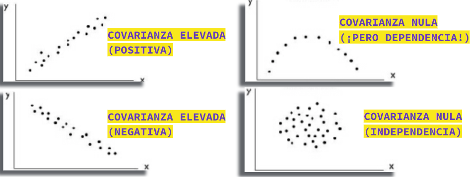

#### 2.2.3 Simulación: variables con relación lineal

¿Y si simulamos dos variables con relación lineal?

```r
set.seed(12345)
x <- rnorm(n = 1e6, mean = 0, sd = 0.5)
y <- 2*x
cov(x, y)
```

```
[1] 0.5013159
```

La covarianza en este caos es 0.50132 y la pregunta es…¿es mucho o poco? Eso no podemos resolverlo hasta hablar de **correlación**: de momento solo podemos decir que, en caso de existir, la relación lineal será **positiva**. Esto cambiaría si la hubiéramos definido $Y$ de otra manera, por ejemplo `y <- -2*x`

```r
y <- -2*x
cov(x, y)
```

```
[1] -0.5013159
```

### 2.3 Matriz de covarianzas

Antes de hablar de correlación, vamos a introducir una **generalización** de una simple covarianza, y es la conocida como **matriz de covarianzas**, y que jugará un papel fundamental en estadística ya que resume un conjunto de datos multivariantes.

La idea de dicha matriz que llamaremos $\Sigma$ es, que si en lugar de tener una sola predictora tenemos $\left(X_1, \ldots, X_p \right)$ covariables, cada elemento $\Sigma_{i,j}$ se defina como

$$\Sigma = \left(\Sigma_{i,j} \right)_{i=1,\ldots,p}^{j=1,\ldots,p} = \begin{pmatrix} s_{x_1 x_1} = s_{x_1}^2 & s_{x_1 x_2} & \ldots & s_{x_1 x_p} \\ s_{x_2 x_1} & s_{x_2 x_2} = s_{x_2}^2 & \ldots & s_{x_2 x_p} \\ \vdots & \vdots & \ddots & \vdots \\ s_{x_p x_1} & s_{x_p x_2} & \ldots & s_{x_p x_p} = s_{x_p}^2 \end{pmatrix}$$

En el futuro veremos como los **autovalores y autovectores de esta matriz** serán fundamentales. Para calcularla en `R` basta con pasarle `cov()` a un dataset (¡importante, solo numéricas!)

```r
library(tidyverse)
starwars |>
  select(where(is.numeric)) |> # importante: solo numéricas
  drop_na() |> # importante: covarianza de ausentes --> ausente
  cov()
```

```
               height       mass birth_year
height       955.5071   715.3057  -2138.334
mass         715.3057 46313.2034  17402.547
birth_year -2138.3336 17402.5466  28603.045
```

### 2.4 Datos agrupados

Un pequeño matiz en caso de que tuviésemos que hacer el **cálculo a mano**: si tenemos una base de datos agrupados (no tenemos el dato en bruto sino los pares de datos únicos $(x_i, y_j)$ y su frecuencia $n_{ij}$), la matriz anterior se calcula como

$$\Sigma = \left(\Sigma_{i,j} \right)_{i=1,\ldots,p}^{j=1,\ldots,p}, \quad \Sigma_{i,j} = s_{x_i x_j} = \frac{1}{n} \sum_{i=1}^{k_i} \sum_{j=1}^{k_j} n_{ij} \left(x_i - \overline{x} \right)\left(y_j - \overline{y} \right)$$

## 3 Correlación

### 3.1 Repaso teórico

Como decíamos, al igual que pasaba con la varianza, la **covarianza depende de las unidades y magnitudes** de los datos, así que lo que haremos será **estandarizar la covarianza**.

Definiremos el **coeficiente correlación lineal (de Pearson)** como la covarianza dividida entre el producto de las desviaciones típicas (algo adimensional)

$$r_{xy} = \rho_{xy} = \frac{s_{xy}}{s_x s_y} = \frac{\overline{x*y} - \overline{x} * \overline{y}}{\sqrt{\overline{x^2} - \overline{x}^2}\sqrt{\overline{y^2} - \overline{y}^2}}$$

#### 3.1.1 Propiedades de la correlación

Es importante entender algunas **propiedades de la correlación**

- **Signo**: mismo signo que la covarianza ya que el denominador es siempre positivo.
- **¿Qué cuantifica?**: sus **valores siempre están entre -1 y 1** por lo que nos sirve como una **escala de la fortaleza de una relación lineal**. Al igual qe con la covarianza **no captura relaciones no lineales**
- **¿Qué dice su signo?** El signo de la correlación nos indicará la **dirección de la dependencia lineal**: si es positiva, la relación será creciente (cuando X crece, Y crece); si es negativa, la relación será decreciente (cuando X crece, Y decrece)
- **¿Qué dice su magnitud?** Más cerca de -1 o 1 implica (a priori…) una relación más fuerte, más cerca de 0 ausencia (a priori…) de relación lineal

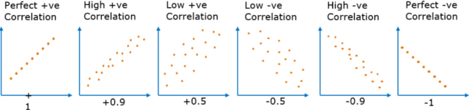

### 3.2 Herramientas en R

Para calcular la correlación entre dos variables en `R` la forma más sencilla es usar la función `cor()`.

**Importante**

Aunque los softwares estadísticos nos devuelven siempre la **cuasi covarianza**, dividido entre $n-1$ y no entre $n$, esto no afecta la correlación (ya que los denominadores se cancelan)

Como hemos hecho antes con la covarianza, podemos tener una **generalización** de una simple correlación, y es la conocida como **matriz de correlaciones**, y que jugará también un papel fundamental en estadística ya que resume un conjunto de datos multivariantes (estandrizados).

La idea de dicha matriz que llamaremos $R$ es, que si en lugar de tener una sola predictora tenemos $\left(X_1, \ldots, X_p \right)$ covariables, cada elemento $r_{i,j}$ se defina como

$$R = \left(r_{i,j} \right)_{i=1,\ldots,p}^{j=1,\ldots,p} = \begin{pmatrix} 1 & r_{x_1 x_2} & \ldots & r_{x_1 x_p} \\ r_{x_2 x_1} & 1 & \ldots & r_{x_2 x_p} \\ \vdots & \vdots & \ddots & \vdots \\ r_{x_p x_1} & r_{x_p x_2} & \ldots & 1 \end{pmatrix}$$

Fíjate que ahora, además de ser simétrica como la matriz de covarianzas, la diagonal es siempre 1 (la correlación entre una variable consigo misma es la máxima posible). Para calcularla en `R` basta con pasarle `cor()` a un dataset (¡importante, solo numéricas!)

```r
library(tidyverse)
starwars |>
  select(where(is.numeric)) |> # importante: solo numéricas
  drop_na() |> # importante: correlación de ausentes --> ausente
  cor()
```

```
               height      mass birth_year
height      1.0000000 0.1075282 -0.4090274
mass        0.1075282 1.0000000  0.4781391
birth_year -0.4090274 0.4781391  1.0000000
```

Una propiedad importante que relaciona ambas matrices. Si tenemos los **datos estandarizados por media y varianza**, la **matriz de covarianzas coincide con la de correlaciones**

$$R\left(X_1, \ldots, X_p \right) = \Sigma \left(\frac{X_1 - \overline{X_1}}{s_{X_1}}, \ldots, \frac{X_p - \overline{X_p}}{s_{X_p}} \right)$$

La **matriz de correlaciones no es más que la matriz de covarianzas cuando los datos están estandarizados**

```r
library(tidyverse)

# Correlación
starwars |>
  select(where(is.numeric)) |>
  drop_na() |>
  cor()
```

```
               height      mass birth_year
height      1.0000000 0.1075282 -0.4090274
mass        0.1075282 1.0000000  0.4781391
birth_year -0.4090274 0.4781391  1.0000000
```

```r
# Covarianza con datos estandarizados
starwars |>
  select(where(is.numeric)) |>
  drop_na() |>
  # Estandarizamos
  mutate(across(everything(), function(x) { (x - mean(x))/sd(x) })) |>
  cov()
```

```
               height      mass birth_year
height      1.0000000 0.1075282 -0.4090274
mass        0.1075282 1.0000000  0.4781391
birth_year -0.4090274 0.4781391  1.0000000
```

Efectivamente es la misma matriz.

#### 3.2.1 Herramientas extras: paquete corrr y paquete corrplot

Para poder hacer un mejor uso de las correlaciones contamos con el paquete `{corrr}` que nos proporciona la matriz de correlaciones en un tibble propio, pudiendo realizar una **profundo análisis exploratorio** de la misma. La función más importante es `correlate()` (el equivalente a `cor()`), que vamos a aplicar al conjunto `mtcars` del paquete `{datasets}`

```r
library(corrr)
mtcars |>
  correlate()
```

```
Correlation computed with
• Method: 'pearson'
• Missing treated using: 'pairwise.complete.obs'
```

```
# A tibble: 11 × 12
   term     mpg    cyl   disp     hp    drat     wt    qsec     vs      am
   <chr>  <dbl>  <dbl>  <dbl>  <dbl>   <dbl>  <dbl>   <dbl>  <dbl>   <dbl>
 1 mpg   NA     -0.852 -0.848 -0.776  0.681  -0.868  0.419   0.664  0.600
 2 cyl   -0.852 NA      0.902  0.832 -0.700   0.782 -0.591  -0.811 -0.523
 3 disp  -0.848  0.902 NA      0.791 -0.710   0.888 -0.434  -0.710 -0.591
 4 hp    -0.776  0.832  0.791 NA     -0.449   0.659 -0.708  -0.723 -0.243
 5 drat   0.681 -0.700 -0.710 -0.449 NA      -0.712  0.0912  0.440  0.713
 6 wt    -0.868  0.782  0.888  0.659 -0.712  NA     -0.175  -0.555 -0.692
 7 qsec   0.419 -0.591 -0.434 -0.708  0.0912 -0.175 NA       0.745 -0.230
 8 vs     0.664 -0.811 -0.710 -0.723  0.440  -0.555  0.745  NA      0.168
 9 am     0.600 -0.523 -0.591 -0.243  0.713  -0.692 -0.230   0.168 NA
10 gear   0.480 -0.493 -0.556 -0.126  0.700  -0.583 -0.213   0.206  0.794
11 carb  -0.551  0.527  0.395  0.750 -0.0908  0.428 -0.656  -0.570  0.0575
# ℹ 2 more variables: gear <dbl>, carb <dbl>
```

**¿Qué diferencias hay?**

1. La salida es a su vez un tibble por lo que podemos **filtrar de manera muy sencilla** quedándonos solo con la información que nos interesa

```r
# Filtramos solo las correlaciones respecto a 3 variables
mtcars |>
  correlate() |>
  filter(term %in% c("mpg", "disp", "gear"))
```

```
Correlation computed with
• Method: 'pearson'
• Missing treated using: 'pairwise.complete.obs'
```

```
# A tibble: 3 × 12
  term     mpg    cyl   disp     hp   drat     wt   qsec     vs     am   gear
  <chr>  <dbl>  <dbl>  <dbl>  <dbl>  <dbl>  <dbl>  <dbl>  <dbl>  <dbl>  <dbl>
1 mpg   NA     -0.852 -0.848 -0.776  0.681 -0.868  0.419  0.664  0.600  0.480
2 disp  -0.848  0.902 NA      0.791 -0.710  0.888 -0.434 -0.710 -0.591 -0.556
3 gear   0.480 -0.493 -0.556 -0.126  0.700 -0.583 -0.213  0.206  0.794 NA
# ℹ 1 more variable: carb <dbl>
```

```r
# Si queremos predecir mpg, filtramos aquellas variables que tienen una correlación (en valor absoluto) superior a 0.7
mtcars |>
  correlate() |>
  filter(abs(mpg) > 0.7)
```

```
Correlation computed with
• Method: 'pearson'
• Missing treated using: 'pairwise.complete.obs'
```

```
# A tibble: 4 × 12
  term     mpg    cyl   disp     hp   drat     wt   qsec     vs     am   gear
  <chr>  <dbl>  <dbl>  <dbl>  <dbl>  <dbl>  <dbl>  <dbl>  <dbl>  <dbl>  <dbl>
1 cyl   -0.852 NA      0.902  0.832 -0.700  0.782 -0.591 -0.811 -0.523 -0.493
2 disp  -0.848  0.902 NA      0.791 -0.710  0.888 -0.434 -0.710 -0.591 -0.556
3 hp    -0.776  0.832  0.791 NA     -0.449  0.659 -0.708 -0.723 -0.243 -0.126
4 wt    -0.868  0.782  0.888  0.659 -0.712 NA     -0.175 -0.555 -0.692 -0.583
# ℹ 1 more variable: carb <dbl>
```

2. Los **valores negativos vienen marcados en rojo**
3. Podemos especificar que valor queremos en la **diagonal**

```r
mtcars |>
  correlate(diag = 1)
```

```
Correlation computed with
• Method: 'pearson'
• Missing treated using: 'pairwise.complete.obs'
```

```
# A tibble: 11 × 12
   term     mpg    cyl   disp     hp    drat     wt    qsec     vs      am
   <chr>  <dbl>  <dbl>  <dbl>  <dbl>   <dbl>  <dbl>   <dbl>  <dbl>   <dbl>
 1 mpg    1     -0.852 -0.848 -0.776  0.681  -0.868  0.419   0.664  0.600
 2 cyl   -0.852  1      0.902  0.832 -0.700   0.782 -0.591  -0.811 -0.523
 3 disp  -0.848  0.902  1      0.791 -0.710   0.888 -0.434  -0.710 -0.591
 4 hp    -0.776  0.832  0.791  1     -0.449   0.659 -0.708  -0.723 -0.243
 5 drat   0.681 -0.700 -0.710 -0.449  1      -0.712  0.0912  0.440  0.713
 6 wt    -0.868  0.782  0.888  0.659 -0.712   1     -0.175  -0.555 -0.692
 7 qsec   0.419 -0.591 -0.434 -0.708  0.0912 -0.175  1       0.745 -0.230
 8 vs     0.664 -0.811 -0.710 -0.723  0.440  -0.555  0.745   1      0.168
 9 am     0.600 -0.523 -0.591 -0.243  0.713  -0.692 -0.230   0.168  1
10 gear   0.480 -0.493 -0.556 -0.126  0.700  -0.583 -0.213   0.206  0.794
11 carb  -0.551  0.527  0.395  0.750 -0.0908  0.428 -0.656  -0.570  0.0575
# ℹ 2 more variables: gear <dbl>, carb <dbl>
```

Además contamos con algunas funciones que nos pueden ayudar:

- `focus()`: realiza un **filtro específico de las variables de interés** (cuidado: hay otra función con el mismo nombre del paquete `{skimr}`)

```r
mtcars |>
  correlate() |>
  corrr::focus(mpg, cyl)
```

```
Correlation computed with
• Method: 'pearson'
• Missing treated using: 'pairwise.complete.obs'
```

```
# A tibble: 9 × 3
  term     mpg    cyl
  <chr>  <dbl>  <dbl>
1 disp  -0.848  0.902
2 hp    -0.776  0.832
3 drat   0.681 -0.700
4 wt    -0.868  0.782
5 qsec   0.419 -0.591
6 vs     0.664 -0.811
7 am     0.600 -0.523
8 gear   0.480 -0.493
9 carb  -0.551  0.527
```

Podemos indicar que **variables queremos quitar** con un signo negativo sobre ellas y `mirror = TRUE`

```r
mtcars |>
  correlate() |>
  corrr::focus(-(mpg:drat), mirror = TRUE)
```

```
Correlation computed with
• Method: 'pearson'
• Missing treated using: 'pairwise.complete.obs'
```

```
# A tibble: 6 × 7
  term      wt   qsec     vs      am   gear    carb
  <chr>  <dbl>  <dbl>  <dbl>   <dbl>  <dbl>   <dbl>
1 wt    NA     -0.175 -0.555 -0.692  -0.583  0.428
2 qsec  -0.175 NA      0.745 -0.230  -0.213 -0.656
3 vs    -0.555  0.745 NA      0.168   0.206 -0.570
4 am    -0.692 -0.230  0.168 NA       0.794  0.0575
5 gear  -0.583 -0.213  0.206  0.794  NA      0.274
6 carb   0.428 -0.656 -0.570  0.0575  0.274 NA
```

- `rearrange()`: nos permite **ordenar por correlación**, de manera que nos agrupa las variables más altamente correladas juntas

```r
mtcars |>
  correlate() |>
  rearrange(absolute = TRUE)
```

```
Correlation computed with
• Method: 'pearson'
• Missing treated using: 'pairwise.complete.obs'
```

```
# A tibble: 11 × 12
   term     mpg     vs    drat      am   gear    qsec    carb     hp     wt
   <chr>  <dbl>  <dbl>   <dbl>   <dbl>  <dbl>   <dbl>   <dbl>  <dbl>  <dbl>
 1 mpg   NA      0.664  0.681   0.600   0.480  0.419  -0.551  -0.776 -0.868
 2 vs     0.664 NA      0.440   0.168   0.206  0.745  -0.570  -0.723 -0.555
 3 drat   0.681  0.440 NA       0.713   0.700  0.0912 -0.0908 -0.449 -0.712
 4 am     0.600  0.168  0.713  NA       0.794 -0.230   0.0575 -0.243 -0.692
 5 gear   0.480  0.206  0.700   0.794  NA     -0.213   0.274  -0.126 -0.583
 6 qsec   0.419  0.745  0.0912 -0.230  -0.213 NA      -0.656  -0.708 -0.175
 7 carb  -0.551 -0.570 -0.0908  0.0575  0.274 -0.656  NA       0.750  0.428
 8 hp    -0.776 -0.723 -0.449  -0.243  -0.126 -0.708   0.750  NA      0.659
 9 wt    -0.868 -0.555 -0.712  -0.692  -0.583 -0.175   0.428   0.659 NA
10 disp  -0.848 -0.710 -0.710  -0.591  -0.556 -0.434   0.395   0.791  0.888
11 cyl   -0.852 -0.811 -0.700  -0.523  -0.493 -0.591   0.527   0.832  0.782
# ℹ 2 more variables: disp <dbl>, cyl <dbl>
```

- `shave()`: nos muestra solo la **diagonal inferior**

```r
mtcars |>
  correlate() |>
  rearrange(absolute = TRUE) |>
  shave()
```

```
Correlation computed with
• Method: 'pearson'
• Missing treated using: 'pairwise.complete.obs'
```

```
# A tibble: 11 × 12
   term     mpg     vs    drat      am   gear   qsec   carb     hp     wt   disp
   <chr>  <dbl>  <dbl>   <dbl>   <dbl>  <dbl>  <dbl>  <dbl>  <dbl>  <dbl>  <dbl>
 1 mpg   NA     NA     NA      NA      NA     NA     NA     NA     NA     NA
 2 vs     0.664 NA     NA      NA      NA     NA     NA     NA     NA     NA
 3 drat   0.681  0.440 NA      NA      NA     NA     NA     NA     NA     NA
 4 am     0.600  0.168  0.713  NA      NA     NA     NA     NA     NA     NA
 5 gear   0.480  0.206  0.700   0.794  NA     NA     NA     NA     NA     NA
 6 qsec   0.419  0.745  0.0912 -0.230  -0.213 NA     NA     NA     NA     NA
 7 carb  -0.551 -0.570 -0.0908  0.0575  0.274 -0.656 NA     NA     NA     NA
 8 hp    -0.776 -0.723 -0.449  -0.243  -0.126 -0.708  0.750 NA     NA     NA
 9 wt    -0.868 -0.555 -0.712  -0.692  -0.583 -0.175  0.428  0.659 NA     NA
10 disp  -0.848 -0.710 -0.710  -0.591  -0.556 -0.434  0.395  0.791  0.888 NA
11 cyl   -0.852 -0.811 -0.700  -0.523  -0.493 -0.591  0.527  0.832  0.782  0.902
# ℹ 1 more variable: cyl <dbl>
```

- `fashion()`: nos ofrece un **resumen más limpio y resumido**

```r
mtcars |>
  correlate() |>
  shave() |>
  fashion()
```

```
Correlation computed with
• Method: 'pearson'
• Missing treated using: 'pairwise.complete.obs'
```